# ttest

Matthew Johnson

October 19, 2017

```r
library(ape)
suppressMessages(library(tidyverse))
data(carnivora)
```

1. Carnivora is a dataset that contains observations about the Carnivora family. GL is the gestation length of the selected family and is measured in days. BW is birth weight in grams.

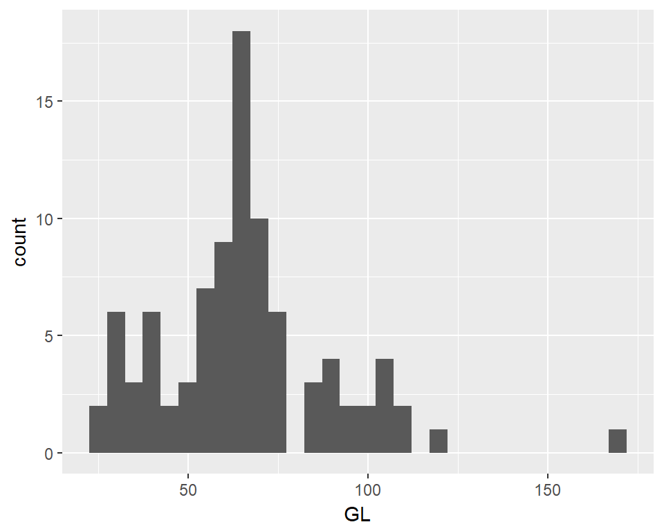

```r
GL <- na.omit(carnivora$GL)
qplot(GL, geom="histogram", bins=30)
```

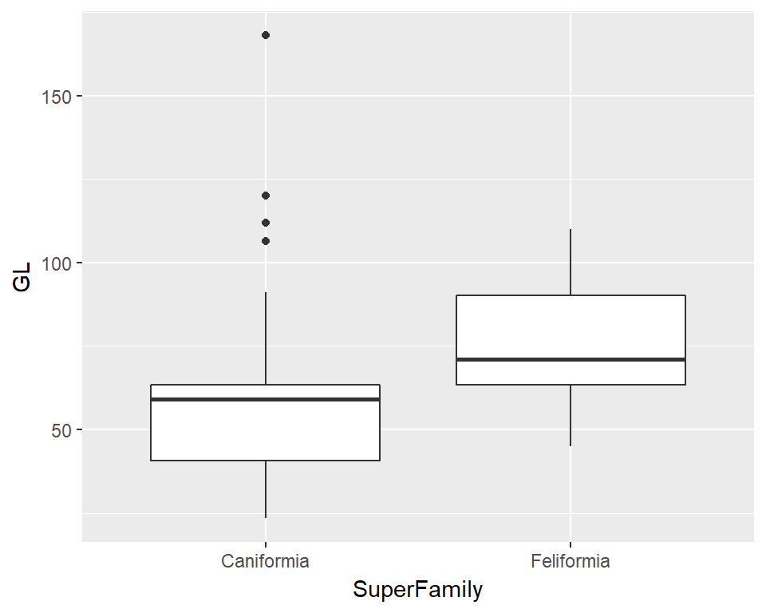

```r
qplot(SuperFamily, GL, data=carnivora, geom = "boxplot")
```

```r
dGL <- carnivora %>%
  select(GL, SuperFamily) %>%
  na.omit() %>%
  group_by(SuperFamily) %>%
  summarise(MnGL = mean(GL, na.rm=TRUE),
            VarGL = var(GL, na.rm=TRUE),
            MedGL = median(GL, na.rm=TRUE),
            SDGL = sd(GL, na.rm=TRUE),
            NumGL = length(GL))
dGL
```

```
## # A tibble: 2 x 6
##   SuperFamily     MnGL    VarGL MedGL     SDGL NumGL
##        <fctr>    <dbl>    <dbl> <dbl>    <dbl> <int>
## 1  Caniformia 58.36346 666.9016    59 25.82444    52
## 2  Feliformia 75.68205 298.2531    71 17.27001    39
```

E-H) One-Sample Hypothesis test H null: Mean gestation length for carnivora is 60 days. H alt: Mean gestation length for carnivora is not 60 days. alpha = 0.02

```r
n <- length(na.omit(GL))
se <- sd(na.omit(GL))/sqrt(n)
mean(na.omit(GL)) + qt(c(.01, .99), n-1)*se
```

```
## [1] 59.81595 71.75548
```

```r
t <- (mean(na.omit(GL)) - 60)/se
p <- 2*(1-pt(abs(t),df= n-1))
```

We are 98% confident that the mean gestation length of Carnivora is between 59.8 and 71.8 days. Our p-value was almost equal to our level of significance, so we failed to reject the null hypothesis. The average length of time a dog or cat spends pregnant is between 60 days and about 72 days.

Two-Sample Hypothesis Test H null: Gestation length of Caniformia and Feliformia is the same. H alt: Gestation length of Caniformia and Feliformia is not the same. alpha = 0.02

```r
with(dGL, {
  tstar <- qt(c(0.01, 0.99), min(n-1))
  -diff(MnGL) + tstar*sqrt(sum(VarGL/n))})
```

```
## [1] -25.032076  -9.605104
```

```r
# p-value
with(dGL, {
  t <- diff(MnGL)/sqrt(sum(VarGL/n))
  2*(1-pt(abs(t), min(n-1)))})
```

```
## [1] 7.593045e-07
```

I am 98% conident that the population difference in mean gestation length between SuperFamilies Caniformia and Feliformia is between -25.03 and -9.61 days. Our p-value is much smaller than our level of significance, so we can reject our null hypothesis. Cats are pregnant longer than dogs by between 9 and 25 days.

```r
url <- "C:/Programming/R stuff/finches.csv"
finches <- read.csv(url)
```

1. Finches is a dataset that contains observations of different finches. Winglength is the length in millimeters.

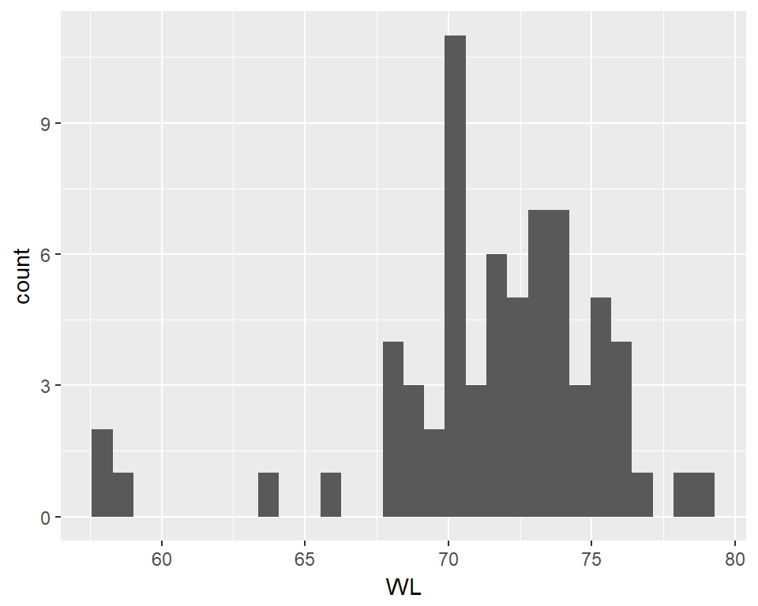

```r
WL <- na.omit(finches$winglength)
qplot(WL, geom="histogram", bins=30)
```

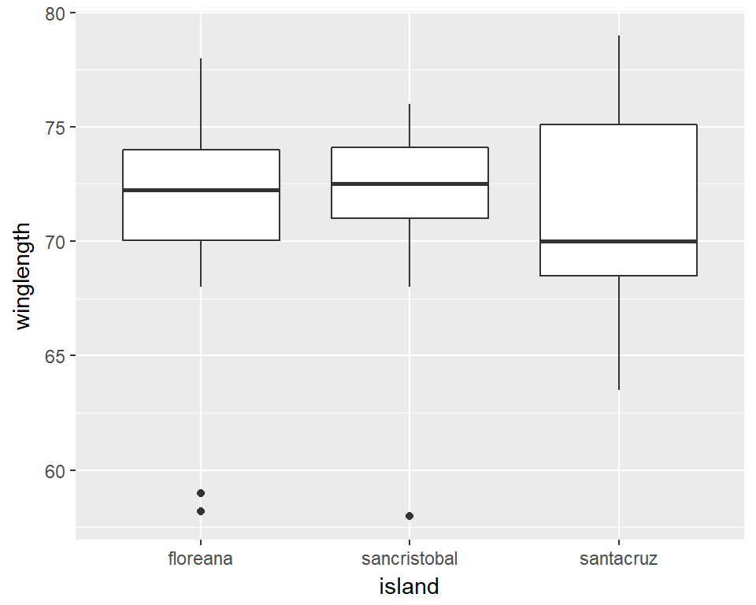

```r
qplot(island, winglength, data=finches, geom = "boxplot")
```

```r
dWL <- finches %>%
  select(winglength, island) %>%
  na.omit() %>%
  group_by(island) %>%
  summarise(MnWL = mean(winglength, na.rm=TRUE),
            VarWL = var(winglength, na.rm=TRUE),
            MedWL = median(winglength, na.rm=TRUE),
            SDWL = sd(winglength, na.rm=TRUE),
            NumWL = length(winglength))
dWL
```

```
## # A tibble: 3 x 6
##         island     MnWL    VarWL MedWL     SDWL NumWL
##         <fctr>    <dbl>    <dbl> <dbl>    <dbl> <int>
## 1     floreana 71.26923 19.90462 72.25 4.461459    26
## 2 sancristobal 72.02963 12.14678 72.50 3.485223    27
## 3    santacruz 71.24667 19.11267 70.00 4.371804    15
```

4. The histogram above has a left skew due to a few very short winglengths. The box plot above shows the different ranges of the middle 50% of the data, santacruz finches having the widest distribution, and sancristobal having the smallest. There is a large enough sample size for these finches to provide us ample data for a normal sample distribution. The Central Limit Theorem states that given a large enough sample size, our sample distribution will be normal.

E/F/G/H) One-Sample Hypothesis test H null: Mean wing length is 60mm. H alt: Mean wing length is not 60mm. alpha = 0.02

```r
WL <- finches$winglength
n2 <- length(na.omit(WL))
se2 <- sd(na.omit(WL))/sqrt(n2)
mean(na.omit(WL)) + qt(c(.01, .99), n2-1)*se2
```

```
## [1] 70.40010 72.73225
```

```r
t2 <- (mean(na.omit(WL)) - 60)/se2
p2<- 2*(1-pt(abs(t2), df= n2-1))
```

We are 98% confident that the mean wing length of population finches is between 70.4 and 72.7 mm. Our p-value was less than 0.00001 and is less than our level of significance, so we can reject the null hypothesis. Finches from islands Santa Cruz, San Cristobal, and Floreana have average wing lengths of between 70 and 73 millimeters.

Two-Sample Hypothesis Test H null: Wing length of finches is the same. H alt: Wing length of finches is not the same. alpha = 0.02

```r
with(dWL, {
  tstar <- qt(c(0.01, 0.99), min(n2-1))
  -diff(MnWL) + tstar*sqrt(sum(VarWL/n2))})
```

```
## [1] -2.827717  2.850281
```

```r
# p-value
with(dWL, {
  t3 <- diff(MnWL)/sqrt(sum(VarWL/n2))
  2*(1-pt(abs(t3), min(n2-1)))})
```

```
## [1] 0.3838232 0.3699523
```

I am 98% conident that the population difference in wing length between Islands Finches is between -2.82mm and 2.85mm. Our p-value is larger than our level of significance, so we fail to reject our null hypothesis. Finches from islands Santa Cruz and Floreana have wing spans similar in length and finches from San Cristobal have slightly longer wing lengths.